# ShapleyForest on Simulated Data: Module-Based DGM

# 3 Single SF Run

We fit SF once on the full dataset to explore its output before the formal comparison.

```r
sf_setup()
```

```r
sc_single <- screen_control(min_ntree = 500L)
sl_single <- select_control(min_ntree = 500L, n_boots = 50L,
                             indep_modules = "M10_indep")

fit <- sf(
  X                 = sim_X,
  y                 = sim_y,
  module_membership = module_membership,
  screen_params     = sc_single,
  select_params     = sl_single,
  backend           = "python",
  verbose           = 1L,
  seed              = 2026L
)
```

## 3.1 Stable set

```r
cat("Stable features selected:", length(fit$feature_list$feature_name), "\n")
head(sort(fit$stability_freq, decreasing = TRUE), 20)
```

[output not shown]

### 3.1.1 Ground-truth validation

```r
stable <- fit$feature_list$feature_name

tp <- length(intersect(stable, T_all))
cat(sprintf("Overall\n"))
cat(sprintf("  M1 (corr large): %d / 3\n", length(intersect(stable, T_large))))
cat(sprintf("  M2 (corr small): %d / 3\n", length(intersect(stable, T_small))))
cat(sprintf("  M10 (indep)    : %d / 3\n", length(intersect(stable, T_ind))))
```

[output not shown]

## 3.2 Stability plot

```r
plot_stability(fit)
```

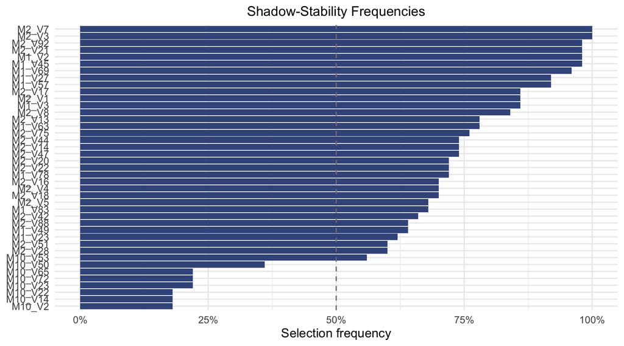

# 4 Model Comparison: Three-Way Split + Cross-Validated Tuning

## 4.1 Design

We compare **six SF variants** formed by two shadow modes × three DML options:

| Variant | Shadow mode | DML |
| --- | --- | --- |
| `split` | split | none |
| `split_dml` | split | standard |
| `split_mdml` | split | marginal |
| `within` | within_module | none |
| `within_dml` | within_module | standard |
| `within_mdml` | within_module | marginal |

We proceed with the following:

0. **Modules from all data.** The `module_membership` from the section above is reused throughout.
1. **Vault a test set** (~20%, stratified) — held out once, scored once, at the very end.
2. **On the remaining ~80% (train):** 5-fold CV tunes the hyperparameter grid *and* compares the six variants on both performance (mean validation-fold AUC) **and** stability (Jaccard of the stable set across folds).
3. **Select one variant** by a pre-specified rule (below), refit every variant on the *full* train set, and evaluate on both the test vault and the ground-truth causal features.

Hyperparameters tuned jointly on the validation folds:

[output not shown]

## 4.2 Setup

```r
library(pROC)
library(caret)
```

```r
VARIANTS <- list(
  split       = list(shadow_mode = "split",         use_dml_residual = FALSE, dml_scope = "indep"),
  split_dml   = list(shadow_mode = "split",         use_dml_residual = TRUE,  dml_scope = "indep"),
  split_mdml  = list(shadow_mode = "split",         use_dml_residual = TRUE,  dml_scope = "all_modules"),
  within      = list(shadow_mode = "within_module", use_dml_residual = FALSE, dml_scope = "indep"),
  within_dml  = list(shadow_mode = "within_module", use_dml_residual = TRUE,  dml_scope = "indep"),
  within_mdml = list(shadow_mode = "within_module", use_dml_residual = TRUE,  dml_scope = "all_modules")
)

GRID <- expand.grid(
  screen_drop = 0.25,
  select_drop = 0.05,
  pi_thr      = c(0.50, 0.60, 0.70),
  stringsAsFactors = FALSE
)

set.seed(2026)
trainval_idx <- as.integer(caret::createDataPartition(
  factor(sim_y), p = 0.8, list = FALSE))
test_idx     <- setdiff(seq_along(sim_y), trainval_idx)

X_tv   <- sim_X[trainval_idx, ]; y_tv   <- sim_y[trainval_idx]
X_test <- sim_X[test_idx, ];     y_test <- sim_y[test_idx]

val_folds <- caret::createFolds(y_tv, k = 5, returnTrain = FALSE)

cat(sprintf("Train: %d  |  Test vault: %d  |  Test positives: %d\n",
            length(y_tv), length(y_test), sum(y_test == 1)))
```

## 4.3 Fit-and-evaluate helper

```r
fit_eval <- function(X_tr, y_tr, X_te, y_te, variant, grid_row) {

  sc  <- screen_control(
    drop_fraction = grid_row$screen_drop,
    min_ntree     = 500L
  )
  sl  <- select_control(
    drop_fraction    = grid_row$select_drop,
    pi_thr           = grid_row$pi_thr,
    n_boots          = 50L,
    min_ntree        = 500L,
    indep_modules    = "M10_indep",
    shadow_mode      = variant$shadow_mode,
    use_dml_residual = variant$use_dml_residual,
    dml_scope        = variant$dml_scope
  )

  fit <- tryCatch(
    sf(X_tr, y_tr,
       module_membership = module_membership,
       screen_params     = sc,
       select_params     = sl,
       backend           = "python",
       seed              = 2026L,
       verbose           = 0L),
    error = function(e) NULL
  )

  stable <- if (!is.null(fit)) fit$feature_list$feature_name else character(0)
  if (length(stable) == 0L)
    return(list(auc = NA_real_, brier = NA_real_,
                n_stable = 0L, stable = character(0)))

  rf   <- ranger::ranger(
    y ~ ., probability = TRUE, num.trees = 300L, seed = 1L,
    data = data.frame(y = factor(y_tr), X_tr[, stable, drop = FALSE])
  )
  prob <- predict(rf,
    data.frame(X_te[, stable, drop = FALSE]))$predictions[, 2]

  list(
    auc      = as.numeric(pROC::auc(y_te, prob, quiet = TRUE)),
    brier    = mean((prob - y_te)^2),
    n_stable = length(stable),
    stable   = stable
  )
}
```

## 4.4 Smoke test

The full tuning sweep is 6 variants × 3 grid rows × 5 validation folds. Before launching, verify that `fit_eval()` runs end-to-end on two grid rows and a single train/test split.

```r
GRID_smoke <- GRID[1:2, ]
print(GRID_smoke)

set.seed(1)
smoke_idx <- caret::createFolds(sim_y, k = 5, returnTrain = FALSE)[[1]]
s_tr <- setdiff(seq_along(sim_y), smoke_idx)
s_te <- smoke_idx

smoke_results <- lapply(seq_len(nrow(GRID_smoke)), function(g) {
  fit_eval(sim_X[s_tr, ], sim_y[s_tr],
           sim_X[s_te, ], sim_y[s_te],
           VARIANTS[["split"]], GRID_smoke[g, ])
})

data.frame(
  grid_row = seq_len(nrow(GRID_smoke)),
  auc      = vapply(smoke_results, `[[`, numeric(1), "auc"),
  brier    = vapply(smoke_results, `[[`, numeric(1), "brier"),
  n_stable = vapply(smoke_results, `[[`, numeric(1), "n_stable")
)
```

If both rows return a finite `auc` and `n_stable > 0`, `fit_eval()` and `sf()` are wired correctly and it is safe to launch the full `tune` sweep below.

## 4.5 Cross-validated tuning and stability

```r
jac_fn <- function(a, b)
  length(intersect(a, b)) / max(length(union(a, b)), 1L)

tune_one <- function(vname) {
  variant <- VARIANTS[[vname]]

  grid_res <- lapply(seq_len(nrow(GRID)), function(g) {
    per_fold <- lapply(seq_along(val_folds), function(fi) {
      vi   <- val_folds[[fi]]
      i_te <- vi; i_tr <- setdiff(seq_along(y_tv), vi)
      r <- fit_eval(X_tv[i_tr, ], y_tv[i_tr],
                    X_tv[i_te, ], y_tv[i_te],
                    variant, GRID[g, ])
      message(sprintf("[%s] g%02d fold%d — auc=%.3f n=%d",
                      vname, g, fi, r$auc, r$n_stable))
      r
    })
    list(
      auc  = mean(vapply(per_fold, `[[`, numeric(1), "auc"), na.rm = TRUE),
      aucs = vapply(per_fold, `[[`, numeric(1), "auc"),
      sets = lapply(per_fold, `[[`, "stable")
    )
  })

  best_g <- which.max(vapply(grid_res, `[[`, numeric(1), "auc"))
  best   <- grid_res[[best_g]]

  jac <- mean(combn(length(best$sets), 2,
                    function(i) jac_fn(best$sets[[i[1]]], best$sets[[i[2]]]),
                    simplify = TRUE))

  message(sprintf(">>> [%s] DONE — best g%02d cv_auc=%.3f jaccard=%.3f",
                  vname, best_g, best$auc, jac))

  list(
    variant  = vname,
    best_row = GRID[best_g, ],
    cv_auc   = best$auc,
    cv_aucs  = best$aucs,
    jaccard  = jac,
    sets     = best$sets
  )
}

tune <- lapply(names(VARIANTS), tune_one)
names(tune) <- names(VARIANTS)
```

## 4.6 Results

### 4.6.1 Variant selection

For each variant, hyperparameters were tuned in the CV sweep above by predictive performance (CV AUC). Variant selection itself uses a different criterion: the **Nogueira size-corrected stability index** $\hat{\Phi}$ (Nogueira, Sechidis & Brown, 2018), which corrects for the inflation that raw Jaccard similarity exhibits when comparing variants with different stable set sizes. Among variants whose $\hat{\Phi}$ falls within one SE of the maximum, we select the most **parsimonious** (smallest mean stable set size $\bar{k}$). Predictive performance is reported for reference but does not drive variant selection.

```r
# ── Nogueira Φ̂ helpers ───────────────────────────────────────────────────────
.phi_hat <- function(sets, d) {
  M     <- length(sets)
  k_bar <- mean(sapply(sets, length))
  if (k_bar == 0 || k_bar >= d) return(NA_real_)
  pairs <- combn(M, 2, simplify = FALSE)
  sym_d <- sapply(pairs, function(idx) {
    a <- sets[[idx[1]]]; b <- sets[[idx[2]]]
    length(a) + length(b) - 2L * length(intersect(a, b))
  })
  v_obs  <- mean(sym_d) / d
  v_null <- 2 * k_bar * (d - k_bar) / d^2
  1 - v_obs / v_null
}

.phi_se <- function(sets, d) {
  M     <- length(sets)
  k_bar <- mean(sapply(sets, length))
  if (k_bar == 0 || k_bar >= d) return(NA_real_)
  v_null <- 2 * k_bar * (d - k_bar) / d^2
  pairs  <- combn(M, 2, simplify = FALSE)
  v_ij   <- sapply(pairs, function(idx) {
    a <- sets[[idx[1]]]; b <- sets[[idx[2]]]
    (length(a) + length(b) - 2L * length(intersect(a, b))) / d
  })
  sd(v_ij) / (sqrt(length(v_ij)) * v_null)
}

d_total <- ncol(sim_X)

summary_tbl <- do.call(rbind, lapply(tune, function(t) {
  phi    <- .phi_hat(t$sets, d_total)
  phi_se <- .phi_se(t$sets, d_total)
  k_bar  <- mean(sapply(t$sets, length))
  data.frame(
    Variant        = t$variant,
    CV_AUC         = round(t$cv_auc, 3),
    CV_AUC_SE      = round(sd(t$cv_aucs, na.rm = TRUE) /
                             sqrt(sum(!is.na(t$cv_aucs))), 3),
    Jaccard        = round(t$jaccard, 3),
    Phi            = round(phi, 3),
    Phi_SE         = round(phi_se, 3),
    k_bar          = round(k_bar, 1),
    `Best pi_thr`  = t$best_row$pi_thr,
    `Best sc_drop` = t$best_row$screen_drop,
    `Best sl_drop` = t$best_row$select_drop,
    check.names = FALSE, row.names = NULL
  )
}))

# 1-SE rule on Φ̂; parsimony tiebreaker (smallest k̄)
top     <- which.max(summary_tbl$Phi)
cutoff  <- summary_tbl$Phi[top] - summary_tbl$Phi_SE[top]
in_band <- summary_tbl[summary_tbl$Phi >= cutoff, ]
best_v  <- in_band$Variant[which.min(in_band$k_bar)]

knitr::kable(summary_tbl, align = "lccccccccc",
             caption = "Per-variant CV performance and Nogueira stability (Φ̂). Variant selection uses 1-SE rule on Φ̂ with parsimony tiebreaker.")
cat("Selected variant (1-SE on Φ̂, parsimony tiebreak):", best_v, "\n")
```

Per-variant CV performance and Nogueira stability (Φ̂). Variant selection uses 1-SE rule on Φ̂ with parsimony tiebreaker.

|  | Variant | CV_AUC | CV_AUC_SE | Jaccard | Phi | Phi_SE | k_bar | Best pi_thr | Best sc_drop | Best sl_drop |
| --- | --- | --- | --- | --- | --- | --- | --- | --- | --- | --- |
| split | split | 0.817 | 0.017 | 0.364 | 0.509 | 0.018 | 49.0 | 0.5 | 0.25 | 0.05 |
| split_dml | split_dml | 0.820 | 0.007 | 0.379 | 0.535 | 0.018 | 33.8 | 0.6 | 0.25 | 0.05 |
| split_mdml | split_mdml | 0.813 | 0.019 | 0.339 | 0.493 | 0.020 | 28.2 | 0.7 | 0.25 | 0.05 |
| within | within | 0.826 | 0.014 | 0.318 | 0.462 | 0.038 | 24.6 | 0.7 | 0.25 | 0.05 |
| within_dml | within_dml | 0.835 | 0.027 | 0.348 | 0.502 | 0.031 | 22.4 | 0.7 | 0.25 | 0.05 |
| within_mdml | within_mdml | 0.812 | 0.015 | 0.323 | 0.461 | 0.036 | 41.4 | 0.5 | 0.25 | 0.05 |

### 4.6.2 Pairwise variant comparison

The five validation folds give five paired AUC values per variant. We test all 15 pairs with a paired Wilcoxon test and apply Benjamini-Hochberg correction.

```r
pairs <- combn(names(VARIANTS), 2, simplify = FALSE)

pw <- do.call(rbind, lapply(pairs, function(p) {
  a <- tune[[p[1]]]$cv_aucs
  b <- tune[[p[2]]]$cv_aucs
  wt <- wilcox.test(a, b, paired = TRUE, exact = FALSE)
  data.frame(`Method A` = p[1], `Method B` = p[2],
             `ΔAUC`     = round(mean(a - b, na.rm = TRUE), 3),
             `p-value`  = round(wt$p.value, 4),
             check.names = FALSE)
}))
pw$`p-adj (BH)` <- round(p.adjust(pw$`p-value`, method = "BH"), 4)
knitr::kable(pw, caption = "Pairwise Wilcoxon tests on validation-fold AUC.")
```

Pairwise Wilcoxon tests on validation-fold AUC.

| Method A | Method B | ΔAUC | p-value | p-adj (BH) |
| --- | --- | --- | --- | --- |
| split | split_dml | -0.003 | 0.7874 | 0.8923 |
| split | split_mdml | 0.004 | 0.7874 | 0.8923 |
| split | within | -0.009 | 0.5839 | 0.8923 |
| split | within_dml | -0.018 | 0.4982 | 0.8923 |
| split | within_mdml | 0.005 | 0.7874 | 0.8923 |
| split_dml | split_mdml | 0.007 | 0.7855 | 0.8923 |
| split_dml | within | -0.005 | 0.8923 | 0.8923 |
| split_dml | within_dml | -0.015 | 0.6845 | 0.8923 |
| split_dml | within_mdml | 0.009 | 0.5862 | 0.8923 |
| split_mdml | within | -0.013 | 0.5879 | 0.8923 |
| split_mdml | within_dml | -0.022 | 0.5896 | 0.8923 |
| split_mdml | within_mdml | 0.002 | 0.8923 | 0.8923 |
| within | within_dml | -0.009 | 0.5839 | 0.8923 |
| within | within_mdml | 0.014 | 0.2807 | 0.8923 |
| within_dml | within_mdml | 0.023 | 0.4098 | 0.8923 |

### 4.6.3 Nogueira stability

```r
library(ggplot2)

phi_df <- data.frame(
  Variant = summary_tbl$Variant,
  Phi     = summary_tbl$Phi,
  Phi_SE  = summary_tbl$Phi_SE
)

ggplot(phi_df, aes(x = reorder(Variant, Phi), y = Phi)) +
  geom_col(fill = "#1F77B4", width = 0.6) +
  geom_errorbar(aes(ymin = Phi - Phi_SE, ymax = Phi + Phi_SE),
                width = 0.25, colour = "grey30") +
  geom_hline(yintercept = 0, linetype = "dashed", colour = "grey40") +
  coord_flip() +
  labs(title    = "Nogueira size-corrected stability per variant",
       subtitle = "Error bars = ±1 SE  |  Dashed line = random-selection null (Φ̂ = 0)",
       x = NULL, y = expression(hat(Phi))) +
  theme_bw()
```

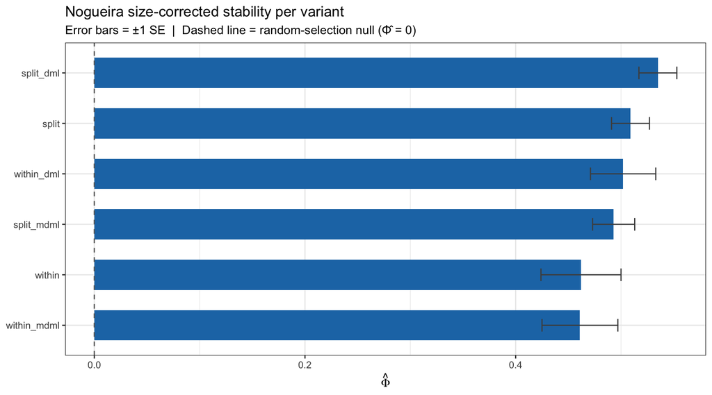

Nogueira size-corrected stability index (Φ̂) per variant with ±1 SE error bars.

### 4.6.4 Final models and held-out test evaluation

We refit **every** variant on the full train+validation set at its locked hyperparameters, then score each on the vaulted test set — the single time the test data is touched. Each `final_models[[v]]$fit` is a complete `shapleyforest` object available for further exploration.

```r
final_models <- lapply(names(VARIANTS), function(vname) {
  variant <- VARIANTS[[vname]]
  row     <- tune[[vname]]$best_row

  sc <- screen_control(
    drop_fraction = row$screen_drop,
    min_ntree     = 500L
  )
  sl <- select_control(
    drop_fraction    = row$select_drop,
    pi_thr           = row$pi_thr,
    n_boots          = 25L,
    min_ntree        = 1000L,
    indep_modules    = "M10_indep",
    shadow_mode      = variant$shadow_mode,
    use_dml_residual = variant$use_dml_residual,
    dml_scope        = variant$dml_scope
  )

  fit <- sf(X_tv, y_tv,
            module_membership = module_membership,
            screen_params     = sc,
            select_params     = sl,
            backend           = "python",
            seed              = 2026L,
            verbose           = 0L)

  stable <- fit$feature_list$feature_name
  rf <- ranger::ranger(
    y ~ ., probability = TRUE, num.trees = 300L, seed = 1L,
    data = data.frame(y = factor(y_tv), X_tv[, stable, drop = FALSE])
  )
  prob <- predict(rf, data.frame(X_test[, stable, drop = FALSE]))$predictions[, 2]

  list(
    fit        = fit,
    test_auc   = as.numeric(pROC::auc(y_test, prob, quiet = TRUE)),
    test_brier = mean((prob - y_test)^2),
    n_stable   = length(stable)
  )
})
names(final_models) <- names(VARIANTS)

test_tbl <- data.frame(
  Variant    = names(final_models),
  Test_AUC   = round(vapply(final_models, `[[`, numeric(1), "test_auc"),   3),
  Test_Brier = round(vapply(final_models, `[[`, numeric(1), "test_brier"), 3),
  n_stable   = vapply(final_models, `[[`, integer(1), "n_stable"),
  Selected   = ifelse(names(final_models) == best_v, "<<", ""),
  row.names  = NULL
)
knitr::kable(test_tbl, align = "lcccc",
             caption = "Held-out test-vault performance (selection made on validation only).")
```

Held-out test-vault performance (selection made on validation only).

| Variant | Test_AUC | Test_Brier | n_stable | Selected |
| --- | --- | --- | --- | --- |
| split | 0.752 | 0.201 | 62 |  |
| split_dml | 0.767 | 0.203 | 60 | << |
| split_mdml | 0.745 | 0.206 | 51 |  |
| within | 0.737 | 0.210 | 37 |  |
| within_dml | 0.752 | 0.208 | 36 |  |
| within_mdml | 0.718 | 0.209 | 57 |  |

### 4.6.5 Ground-truth feature recovery

The key evaluation unique to this simulation: for each variant’s final model, how many of the nine causal features are recovered? Recall and precision are computed against the known `T_all` set. The correlated-module columns (M1, M2) and independent-module column (M10) are reported separately to reveal whether SF’s split-pool and DML designs help at recovering each source.

```r
cat("Selected variant:", best_v, "\n\n")

gt_tbl <- do.call(rbind, lapply(names(final_models), function(v) {
  s  <- final_models[[v]]$fit$feature_list$feature_name
  tp <- length(intersect(s, T_all))
  data.frame(
    Variant    = v,
    Recall_M1  = length(intersect(s, T_large)),
    Recall_M2  = length(intersect(s, T_small)),
    Recall_M10 = length(intersect(s, T_ind)),
    Total_TP   = tp,
    Recall     = round(tp / length(T_all), 3),
    Precision  = round(tp / max(length(s), 1L), 3),
    n_stable   = length(s),
    Selected   = ifelse(v == best_v, "<<", ""),
    row.names  = NULL
  )
}))
knitr::kable(gt_tbl, align = "lcccccccc",
             caption = "Ground-truth feature recovery per variant (final models, full train set).")
```

Ground-truth feature recovery per variant (final models, full train set).

| Variant | Recall_M1 | Recall_M2 | Recall_M10 | Total_TP | Recall | Precision | n_stable | Selected |
| --- | --- | --- | --- | --- | --- | --- | --- | --- |
| split | 2 | 3 | 3 | 8 | 0.889 | 0.129 | 62 |  |
| split_dml | 2 | 3 | 3 | 8 | 0.889 | 0.133 | 60 | << |
| split_mdml | 2 | 3 | 3 | 8 | 0.889 | 0.157 | 51 |  |
| within | 2 | 2 | 3 | 7 | 0.778 | 0.189 | 37 |  |
| within_dml | 2 | 2 | 3 | 7 | 0.778 | 0.194 | 36 |  |
| within_mdml | 2 | 3 | 3 | 8 | 0.889 | 0.140 | 57 |  |

### 4.6.6 Bootstrap selection frequency

The final model is a single fit on `X_tv`. To assess which features are *consistently* selected across different subsets of patients — not just in one run — we repeat the selected variant at its locked hyperparameters on `B = 100` random 80% subsamples of the training set (without replacement). The resulting selection frequency for each feature is the fraction of runs in which it entered the stable set. Because we aggregate across 100 runs, each individual fit uses `n_boots = 15` (fewer bootstraps per run) without materially affecting the aggregate frequency estimate.

```r
row_best     <- tune[[best_v]]$best_row
variant_best <- VARIANTS[[best_v]]

best_sc <- screen_control(
  drop_fraction = row_best$screen_drop,
  min_ntree     = 500L
)
best_sl <- select_control(
  drop_fraction    = row_best$select_drop,
  pi_thr           = row_best$pi_thr,
  n_boots          = 15L,
  min_ntree        = 500L,
  indep_modules    = "M10_indep",
  shadow_mode      = variant_best$shadow_mode,
  use_dml_residual = variant_best$use_dml_residual,
  dml_scope        = variant_best$dml_scope
)

B        <- 100L
sub_size <- floor(0.8 * nrow(X_tv))

boot_sets <- lapply(seq_len(B), function(b) {
  idx   <- sample(nrow(X_tv), sub_size, replace = FALSE)
  fit_b <- tryCatch(
    sf(X_tv[idx, ], y_tv[idx],
       module_membership = module_membership,
       screen_params     = best_sc,
       select_params     = best_sl,
       backend           = "python",
       seed              = b,
       verbose           = 0L),
    error = function(e) NULL
  )
  message(sprintf("boot %03d/%d — %s", b, B,
                  if (is.null(fit_b)) "FAILED"
                  else sprintf("n_stable=%d", nrow(fit_b$feature_list))))
  if (is.null(fit_b)) character(0) else fit_b$feature_list$feature_name
})

# Selection frequency per feature
freq_vec <- sort(
  sapply(colnames(X_tv), function(f) mean(sapply(boot_sets, function(s) f %in% s))),
  decreasing = TRUE
)
freq_df <- data.frame(
  feature   = names(freq_vec),
  frequency = as.numeric(freq_vec),
  source    = ifelse(names(freq_vec) %in% T_large, "M1 (causal)",
              ifelse(names(freq_vec) %in% T_small, "M2 (causal)",
              ifelse(names(freq_vec) %in% T_ind,   "M10 (causal)",
                                                    "Non-causal")))
)
freq_df <- freq_df[freq_df$frequency > 0, ]
```

```r
library(ggplot2)

# Identify which module label corresponds to each causal group
m1_mod  <- unique(module_membership[T_large])
m2_mod  <- unique(module_membership[T_small])
m10_mod <- unique(module_membership[T_ind])

feat_mod <- module_membership[freq_df$feature]
freq_df$panel <- ifelse(feat_mod == m1_mod,  "M1 module",
                 ifelse(feat_mod == m2_mod,  "M2 module",
                 ifelse(feat_mod == m10_mod, "M10 module", "Other modules")))
freq_df$panel <- factor(freq_df$panel,
  levels = c("M1 module", "M2 module", "M10 module", "Other modules"))

top_per_module <- do.call(rbind, lapply(levels(freq_df$panel), function(p) {
  sub <- freq_df[freq_df$panel == p, ]
  head(sub[order(-sub$frequency), ], 10)
}))
top_per_module$feature <- reorder(top_per_module$feature, top_per_module$frequency)

p_boot <- ggplot(top_per_module, aes(x = feature, y = frequency, fill = source)) +
  geom_col(width = 0.7) +
  scale_fill_manual(values = c("M1 (causal)"  = "#D62728",
                                "M2 (causal)"  = "#FF7F0E",
                                "M10 (causal)" = "#2CA02C",
                                "Non-causal"   = "#AEC7E8")) +
  geom_hline(yintercept = 0.5, linetype = "dashed", colour = "grey40") +
  facet_wrap(~ panel, scales = "free_y", ncol = 2) +
  coord_flip() +
  labs(title    = sprintf("Bootstrap selection frequency — %s", best_v),
       subtitle = sprintf("B = %d runs, 80%% subsample (n = %d)", B, sub_size),
       x = NULL, y = "Selection frequency", fill = "Feature type") +
  theme_bw()
print(p_boot)
```

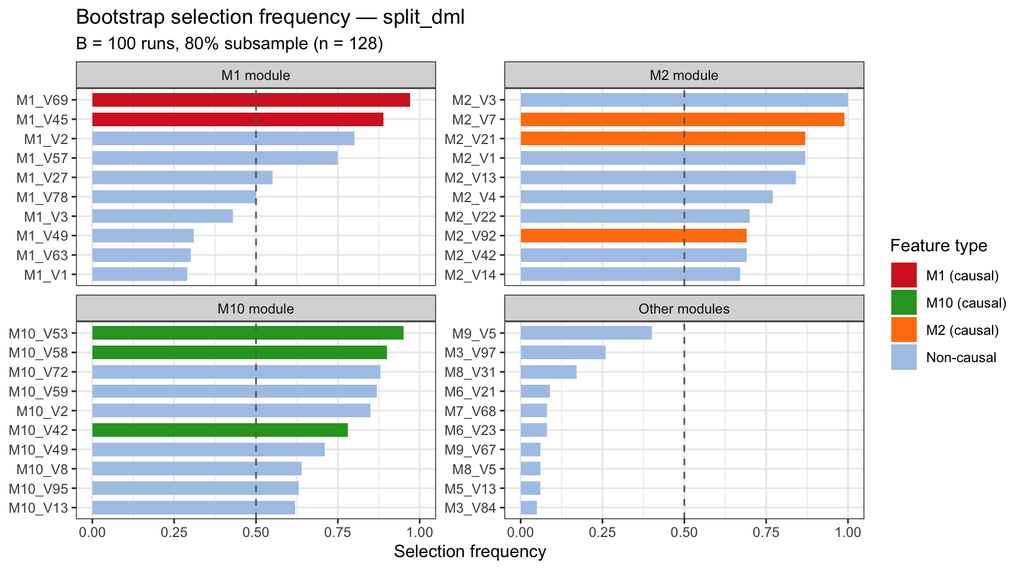

```r
library(ggplot2)
saveRDS(
  list(
    p_stability  = plot_stability(fit),
    p_importance = plot_importance(fit, top_n = 20),
    p_jaccard    = ggplot(phi_df, aes(x = reorder(Variant, Phi), y = Phi)) +
                     geom_col(fill = "#1F77B4", width = 0.6) +
                     geom_errorbar(aes(ymin = Phi - Phi_SE, ymax = Phi + Phi_SE),
                                   width = 0.25, colour = "grey30") +
                     geom_hline(yintercept = 0, linetype = "dashed", colour = "grey40") +
                     coord_flip() +
                     labs(title    = "Nogueira size-corrected stability per variant",
                          subtitle = "Error bars = ±1 SE  |  Dashed line = random-selection null (Φ̂ = 0)",
                          x = NULL, y = expression(hat(Phi))) +
                     theme_bw(),
    summary_tbl  = summary_tbl,
    pw           = pw,
    test_tbl     = test_tbl,
    gt_tbl       = gt_tbl,
    p_boot       = p_boot,
    freq_df      = freq_df
  ),
  "simulation_results.rds"
)
```

# 5 Reporting Checklist

[output not shown]